# Using fastsimcoal

J. Ignacio Lucas Lledó

23/7/2022

## The data

Here the goal is to use fastsimcoal2 to model the split of the ancestral fish population that colonized the two lakes sampled in Norway. Thus, I need first to filter the VCF to include only fish from the Arctic region. As usual, we start from the original, dirty VCF, we remove unwanted individuals and then filter sites again. In order to determine what individuals are from the Arctic lakes, I would use the original file. Note that in folder `2022-05-04` we created a file, `2022-05-04/TheWorst.txt`, with the identifiers of fish with the least data, that should be removed. They include some Arctic fish.

```bash
VCF='../2022-04-22/assem2_outfiles/assem2.vcf'
REMOVABLE='../2022-05-04/TheWorst.txt'
FISHDATA='../../data/Fish_clean.tsv'

if [ ! -e Arctic.txt ]; then
   cut -f 1,4 $FISHDATA | grep "Arctic" | cut -f 1 > Arctic.txt
fi

if [ ! -e arctic.recode.vcf ]; then
   if [ ! -e dirty.recode.vcf ]; then
      vcftools --vcf $VCF \
               --out dirty \
               --keep Arctic.txt \
               --remove $REMOVABLE \
               --recode \
               --recode-INFO-all
   fi
   vcftools --vcf dirty.recode.vcf \
            --out arctic \
            --thin 500 \
            --remove-indels \
            --mac 1 \
            --max-alleles 2 \
            --max-meanDP 1000 \
            --max-missing-count 12 \
            --recode --recode-INFO-all
   if [ -e dirty.recode.vcf ]; then rm dirty.recode.vcf; fi
fi
```

```bash
if [ ! -e arctic.recode.alleleCount.txt ]; then
   gawk 'BEGIN{
      print "#REF\tALT\tMissing\tTotal"
   }(/^[^#]/){
      delete F
      for (i=10;i<=NF;i++) {
         split($i, A, /:/)
         split(A[1], B, /\//)
         F[B[1]]++
         F[B[2]]++
      }
      print F["0"] "\t" F["1"] "\t" F["."] + 0 "\t" F["0"] + F["1"] + F["."]
   }' arctic.recode.vcf > arctic.recode.alleleCount.txt
fi
```

Note that when filtering the VCF, I use `--mac 1`, while we had used `--mac 2` in other occasions. The reason is to avoid biases in the SFS. However, I am afraid the SFS will necessarily be biased, due to ascertainment and downsampling. First, sites are selected for being variable, and indeed all sites in `arctic.recode.vcf` have at least one allele different from the rest. Thus, the zero category in the SFS should be empty. However, to deal with missing data we will downsample the populations with `easySFS` (see below). That is, instead of estimating the SFS for the 54 fish from Langfjordvatn and the 60 fish from Suopatjavri, we estimate an SFS for a theoritcal sample of, say 50 and 50 fish, with no missing data. The problem is that then, because the original VCF includes sites where only one individual is heterozygous, when downsampling we expect those sites to be monomorphic. The zero-category in the SFS becomes populated, but in a very biased way. I definitely don’t want to use the count of monomorphic sites in the estimation. See below how Fastsimcoal2 let us ignore (partially) those sites.

## PCA

Just to make sure that the lake is a good criteria to separate populations in the Arctic region.

```r
suppressMessages(library('ape'))
suppressMessages(library('pegas'))
suppressMessages(library('seqinr'))
suppressMessages(library('ggplot2'))
suppressMessages(library('adegenet'))
library('MetBrewer')
library(kableExtra)

arc <- read.vcf('arctic.recode.vcf', from = 1, to = 100000, quiet = TRUE)
arc <- as.data.frame(arc)
for (i in 1:dim(arc)[2]) arc[,i] <- as.character(arc[,i])
arc[arc == './.'] <- NA

arc.gi <- df2genind(arc, sep = '/', type = 'codom', ploidy = 2)
sum(is.na(arc.gi@tab))
```

```
## [1] 84030
```

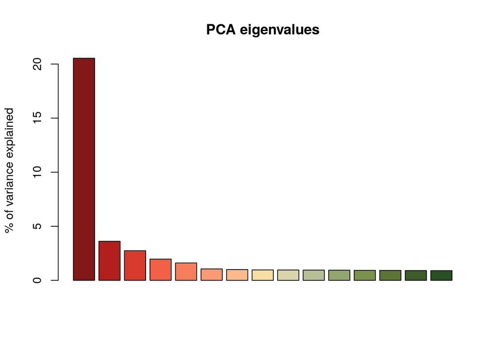

```r
X <- tab(arc.gi, NA.method = 'mean')
pca3 <- dudi.pca(X, scale=FALSE, scannf=FALSE, nf=3)
barplot(100 * pca3$eig[1:15] / sum(pca3$eig), main = 'PCA eigenvalues',
        col = met.brewer('Paquin', 15), ylab = "% of variance explained")
```

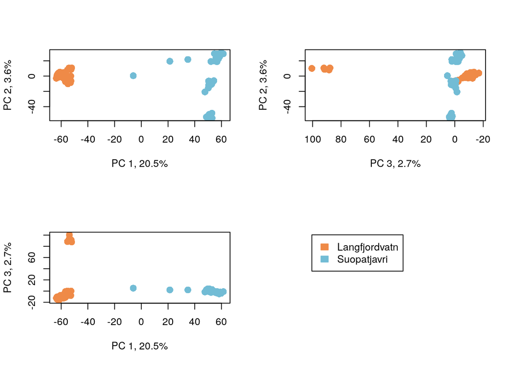

```r
PercentVar <- head(100 * pca3$eig / sum(pca3$eig))

DATA <- '../../data/Fish_clean2.tsv'
Fish <- read.table(DATA, header = TRUE, sep = '\t')
row.names(Fish) <- Fish$Fish_code
arc.gi@pop <- droplevels(Fish[row.names(arc.gi@tab), 'Lake'])
col  <- met.brewer('Hiroshige', 2)
#colt <- transp(col, 0.6)
par(mfrow = c(2,2))
plot(pca3$li$Axis1, pca3$li$Axis2,
     xlab = sprintf("PC 1, %.1f%%", PercentVar[1]),
     ylab = sprintf("PC 2, %.1f%%", PercentVar[2]),
     col = col[arc.gi@pop], pch = 16, cex = 1.5)
plot(pca3$li$Axis3, pca3$li$Axis2,
     xlim = c(max(pca3$li$Axis3), min(pca3$li$Axis3)),
     xlab = sprintf("PC 3, %.1f%%", PercentVar[3]),
     ylab = sprintf("PC 2, %.1f%%", PercentVar[2]),
     col = col[arc.gi@pop], pch = 16, cex = 1.5)
plot(pca3$li$Axis1, pca3$li$Axis3,
     xlab = sprintf("PC 1, %.1f%%", PercentVar[1]),
     ylab = sprintf("PC 3, %.1f%%", PercentVar[3]),
     col = col[arc.gi@pop], pch = 16, cex = 1.5)
plot(c(-40, 20), c(-20, 40), type = 'n', axes = FALSE, ann = FALSE)
legend(-40, y = 40, legend = levels(arc.gi@pop), fill = col, border= col)
```

```r
par(mfrow = c(1,1))
```

The first component, accumulating more than 20% of the variation, separates fish between lakes. Thus, I assume the two lakes are two populations or species.

## Estimation of the site frequency spectrum (SFS)

I have installed easySFS, by Isaac Overcast. To run it, I need to activate the conda environment called “easySFS”. And I need a population file. I assume the population file may include individuals other than those in the VCF.

```bash
eval "$(command conda 'shell.bash' 'hook' 2> /dev/null)"
FISHDATA='../../data/Fish_clean2.tsv'
conda activate easySFS
if [ ! -e popmap.txt ]; then
   # Using lakes as population, because I only have Arctic fish in the VCF.
   if [ ! -e SamplesInVCF.txt ]; then
      grep "#CHROM" arctic.recode.vcf | \
      gawk '{for (i = 10; i <= NF; i++) print $i}' > SamplesInVCF.txt
   fi
   cut -f 1,2 $FISHDATA | tail -n +2 | grep -F -f SamplesInVCF.txt > popmap.txt
fi

if [ ! -d downsample ]; then
   if [ ! -e projection_preview.txt ]; then
      easySFS -a -i arctic.recode.vcf -p popmap.txt --preview > projection_preview.txt
   fi
   easySFS -a -i arctic.recode.vcf -p popmap.txt --proj 96,110 -o downsample
fi
conda deactivate
```

```
## bash: cannot set terminal process group (32947): Inappropriate ioctl for device
## bash: no job control in this shell
```

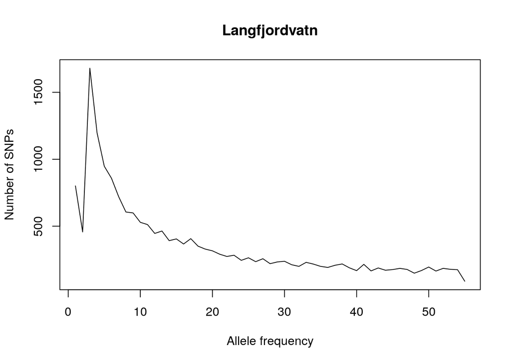

```r
joint <- as.matrix(read.table('fullsample/fastsimcoal2/arctic_jointMAFpop1_0.obs',
                              skip = 1, header = TRUE))
Lang  <- t(as.matrix(read.table('fullsample/fastsimcoal2/Langfjordvatn_MAFpop0.obs',
                                skip = 1, header = TRUE)))
Suo   <- t(as.matrix(read.table('fullsample/fastsimcoal2/Suopatjavri_MAFpop0.obs',
                                skip = 1, header = TRUE)))
plot(Lang[1:55], type = 'l', xlab = 'Allele frequency',
     ylab = 'Number of SNPs', main = 'Langfjordvatn')
```

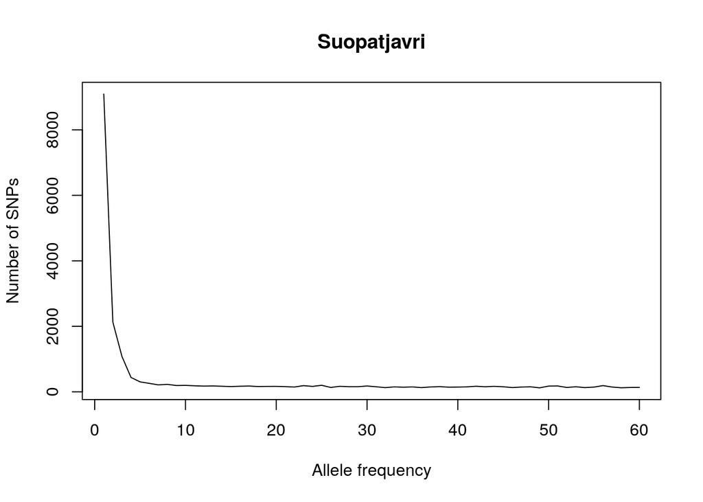

```r
plot(Suo[1:60], type = 'l', xlab = 'Allele frequency',
     ylab = 'Number of SNPs', main = 'Suopatjavri')
```

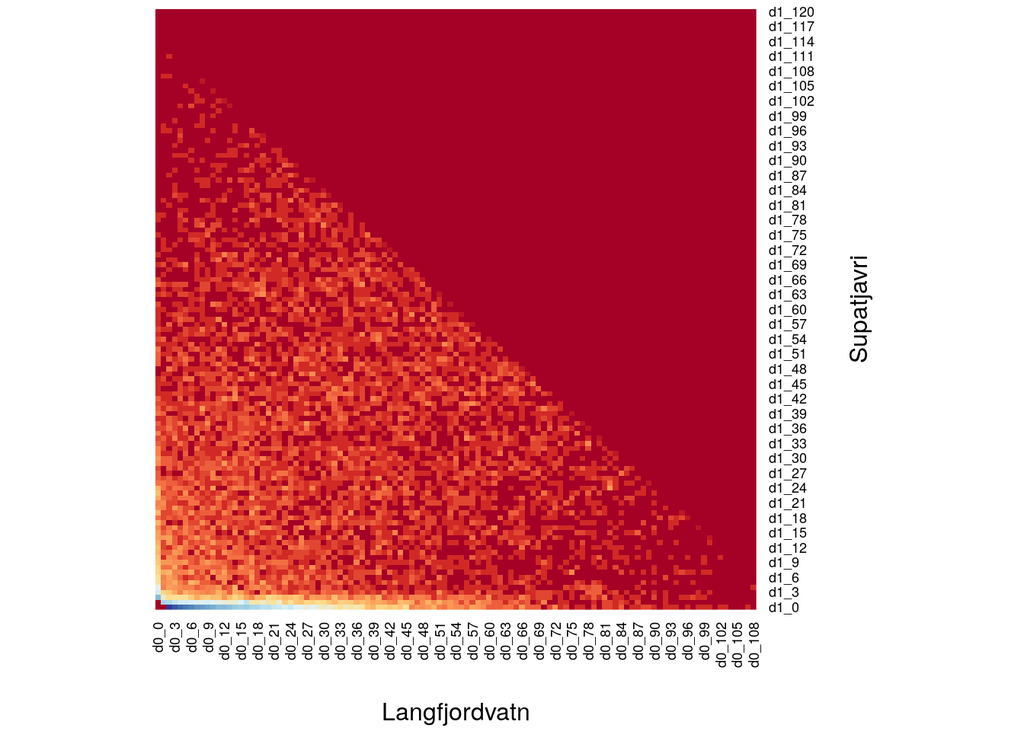

```r
library("RColorBrewer")
col <- colorRampPalette(brewer.pal(10, "RdYlBu"))(256)
heatmap(log(joint + 1), Rowv = NA, Colv = NA, xlab = 'Langfjordvatn',
        ylab = 'Supatjavri', col = col, scale = 'none')
```

The site frequency spectra of the two lakes suggest that Langfjordvatn has much more genetic diversity than Suopatjavri. This is in agreement with the ML phylogeny of the individuals, where fish from Suopatjavri form a clade inside the clade formed by Langfjordvatn fish. However, the small number of sites where the minor allele appears only once in Langfjordvatn makes me doubt of the validity of this SFS. I suspect it could be an artifact, due to lack of power to detect singletons.

The SFS obtained are *projections*, even when the number of chromosomes *subsampled* is equal to the total number of available chromosomes. For example, there are 54 fish from Langfjordvatn (108 chromosomes) and 60 fish from Suopatjavri (120 chromosomes) and when all of them were requested to the easysSFS program, we end up with much fewer SNPs than there were originally: 19541 SNPs in Langfjordvatn; 22024, in Suopatjavri; and only 16830 in the joint dataset. Originally, there were 31411 SNPs in the VCF. Therefore, it is not surprising that the row- or column totals in the joint SFS are different from the numbers of SNPs in each populations.

The joint SFS suggests a common recent history of the two populations: few SNPs are common in one population and rare in the other. And the most abundant class of SNPs are those the minor allele of which is at low frequency in both populations.

## Running Fastsimcoal2

### Template file

Below I transcribe a template file describing a model with two populations that split a while ago, and might have exchanged some individuals at some time afterwards. The two populations are the two lakes. Instead of using a migration matrix to represent the admixture event, I will assume it was a single event. To simplify, in the following template, I assume that population 1 (Suopatjavri) is the one founded later and receiving migrants from population 0. This is the template file for **model 0**.

```bash
//Number of population samples (demes)
2
//Population effective sizes (number of genes)
NPOP0
NPOP1
//Sample sizes
96
110
//Growth rates
0
0
//Number of migration matrices
0
//historical event: time, source, sink, migrants, new size, new growth rate, migr. matrix.
3 historical event
T1 1 0 MIG     1 0 0
T2 1 1   0 0.001 0 0
T2 1 0   1     1 0 0
//Number of independent loci [chromosomes]
1 0
//Per chromosome: Number of linkage blocks
1
//per Block: data type, num loci, rec. rate and mut rate + optional parameters
FREQ 1 0 2.5e-8 OUTEXP
```

### Estimation file

In the SFS, we do not have an unbiased estimate of the zero class (the monomorphic sites). Thus, we need to exclude them from the analysis, using the `--removezeroSFS` option in the command line. The manual warns that this option requieres one parameter to be *fixed*. That is, I need to declare one of the parameters as a *reference* in the .est file. I choose the ancestral population size, NPOP0. This forces me to use the `--minnumloops` option as well. This option makes the optimization process to use whatever count of monomorphic sites we have in the SFS during the first *n* steps, and then fix the reference parameter to the value obtained, to end up estimating the rest of the parameters without taking the monomorphic sites into account. Bizarre.

```bash
// Priors and rules file
// *********************

[PARAMETERS]
//#isInt? #name #dist. #min #max
//all N are in number of haploid individuals
1 NPOP0 unif    100    1000000 output reference
1 NPOP1 unif    100    1000000 output
1 T1    logunif  10      10000 output
0 MIG   unif      0        0.5 output
1 T2    unif     T1      50000 output paramInRange

[COMPLEX PARAMETERS]
```

I noticed the program fails without an error message (other than “core dumped”) if “[COMPLEX PARAMETERS]” is not present in the file. Also, I suspect that the limits of log-uniformly-distributed variables are limits in the log scale.

In **model 0** I assume Suopatjavri population was started by a few fish, representing no more than 0.001 the final population size in that lake. The only difference in **model 1** is that the relative size of the bottleneck is set as another parameter to be estimated (*NECK*).

### Execution to estimate the parameters of model 0

In order to estimate the parameters, the data (observed SFS) must be in the same folder, and with a specific name. The name of the input file encodes the kind of SFS being used: derived allele frequencies (DAF) or minor allele frequencies (“folded” SFS or MAF); one, two or more populations

```bash
for run in $(seq 1 100); do
   rundir=$(printf "model0/run%03i" $run)
   if [ ! -d $rundir ]; then
      mkdir $rundir
   fi
   if [ ! -e $rundir/arctic.tpl ]; then
      cp model0/arctic.tpl $rundir/arctic.tpl
   fi
   if [ ! -e $rundir/arctic.est ]; then
      cp model0/arctic.est $rundir/arctic.est
   fi
   if [ ! -e $rundir/arctic_jointMAFpop1_0.obs ]; then
      ln -sr downsample/fastsimcoal2/arctic_jointMAFpop1_0.obs \
             $rundir/arctic_jointMAFpop1_0.obs
   fi
   if [ ! -e $rundir/arctic.par ]; then
      cd $rundir
      fsc27 --tplfile arctic.tpl \
            --numsims 10000 \
            --msfs \
            --estfile arctic.est \
            --maxlhood \
            --numloops 50 \
            --minnumloops 25 \
            --cores 0 \
            --removeZeroSFS \
            --quiet &> fsc27.log
      cd ../..
   fi
done

if [ ! -e model0/summary.txt ]; then
   echo -e "NPOP0\tNPOP1\tT1\tMIG\tT2\tRescale\tMaxEstLhood\tMaxObsLhood" > model0/summary.txt
   find model0 -name arctic.bestlhoods -exec cat '{}' \; | \
   grep -v "^NPOP0" >> model0/summary.txt
fi
```

### Execution to estimate the parameters of model 1

In model0 the bottleneck suffered during colonization of Suopatjavri was fixed to one thousandth the population size. In model 1 I relax this assumption and estimate the bottleneck relative to the final size of that population.

```bash
for run in $(seq 1 100); do
   rundir=$(printf "model1/run%03i" $run)
   if [ ! -d $rundir ]; then
      mkdir $rundir
   fi
   if [ ! -e $rundir/arctic.tpl ]; then
      cp model1/arctic.tpl $rundir/arctic.tpl
   fi
   if [ ! -e $rundir/arctic.est ]; then
      cp model1/arctic.est $rundir/arctic.est
   fi
   if [ ! -e $rundir/arctic_jointMAFpop1_0.obs ]; then
      ln -sr downsample/fastsimcoal2/arctic_jointMAFpop1_0.obs \
             $rundir/arctic_jointMAFpop1_0.obs
   fi
   if [ ! -e $rundir/arctic.par ]; then
      cd $rundir
      fsc27 --tplfile arctic.tpl \
            --numsims 10000 \
            --msfs \
            --estfile arctic.est \
            --maxlhood \
            --numloops 50 \
            --minnumloops 25 \
            --cores 0 \
            --removeZeroSFS \
            --quiet &> fsc27.log
      cd ../..
   fi
done

if [ ! -e model1/summary.txt ]; then
   echo -e "NPOP0\tNPOP1\tT1\tMIG\tT2\tRescale\tMaxEstLhood\tMaxObsLhood" > model1/summary.txt
   find model1 -name arctic.bestlhoods -exec cat '{}' \; | \
   grep -v "^NPOP0" >> model1/summary.txt
fi
```

## Results

The absolute value of the population size estimates probably depend on the predetermined mutation rate. And estimates of times of events depend in turn on population sizes. If I express times relative to population sizes, I may understand this better. For example, the time to an assumed migration event from Langfjordvatn (population 0) to Suopatjavri (populatin 1) can be expressed in units of coalescence in Suopatjavri by dividing T1 by NPOP1. Recall population sizes are expressed as chromosome numbers, as if populations were haploid. Thus, a number of generations equal to the population size is the expected time of coalescence of two randomly picked genes. The time T2 when Suopatjavri’s population started can also be expressed in the same units.

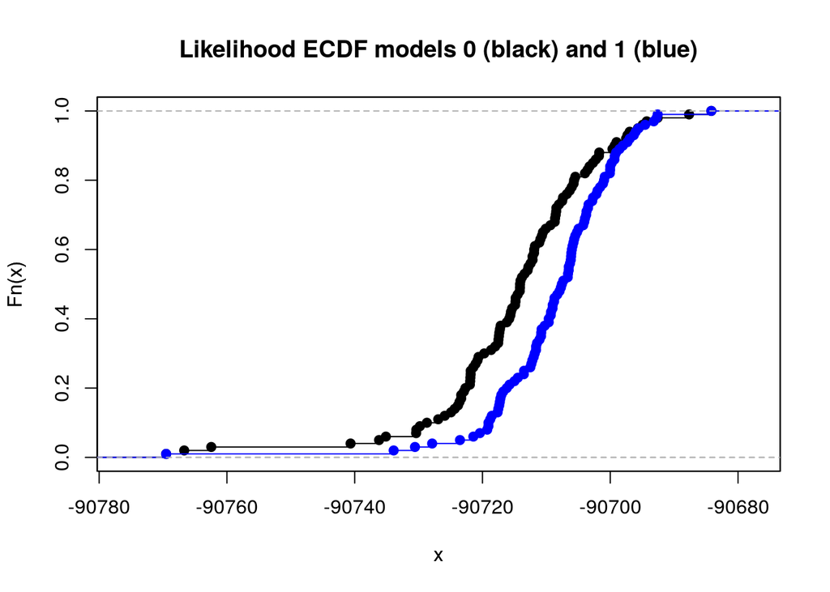

```r
library(ggplot2)
model0 <- read.table('model0/summary.txt', header = TRUE)
model1 <- read.table('model1/summary.txt', header = TRUE)
plot(ecdf(model0$MaxEstLhood), main = '')
par(new = TRUE)
plot(ecdf(model1$MaxEstLhood), col = 'blue', xaxt = 'n', yaxt = 'n',
     main = 'Likelihood ECDF models 0 (black) and 1 (blue)')
```

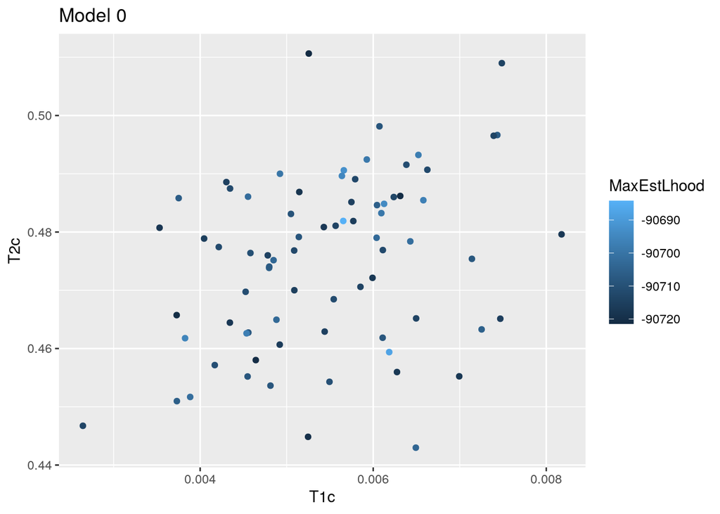

```r
par(new = FALSE)
# A few estimates from each model are much less likely than others.
# I select only the 75 best estimates in each model:
model0 <- model0[model0$MaxEstLhood > quantile(model0$MaxEstLhood, 0.25),]
model1 <- model1[model1$MaxEstLhood > quantile(model1$MaxEstLhood, 0.25),]


model0$T2c <- model0$T2 / model0$NPOP1
model0$T1c <- model0$T1 / model0$NPOP1
ggplot(data = model0, mapping = aes(x = T1c, y = T2c, color = MaxEstLhood)) +
   geom_point() + ggtitle('Model 0')
```

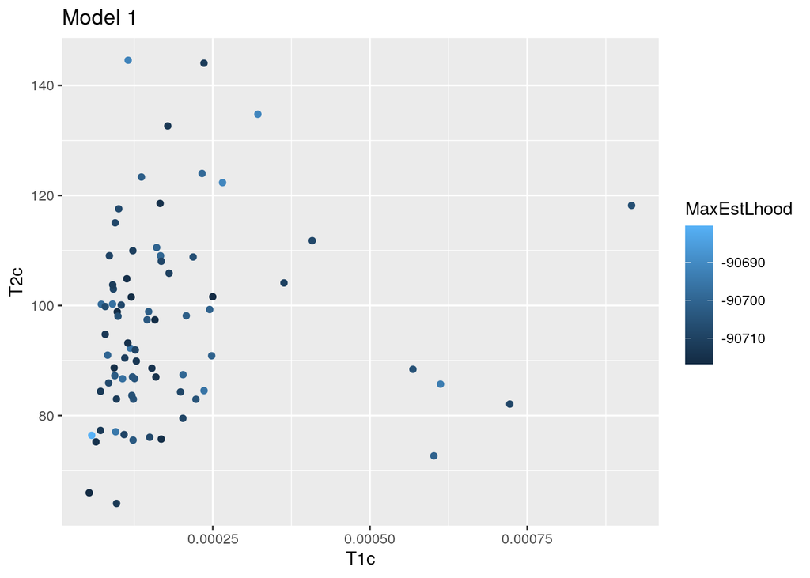

```r
model1$T2c <- model1$T2 / model1$NPOP1
model1$T1c <- model1$T1 / model1$NPOP1
ggplot(data = model1, mapping = aes(x = T1c, y = T2c, color = MaxEstLhood)) +
   geom_point() + ggtitle('Model 1')
```

Both models suggest a recent migration event must have happened very recently (a small fraction of a coalescent unit of time ago). But they differ in the time of divergence: if we allow for a less dramatic bottleneck when founding Suopatjavri, then the divergence seem to have happened a much longer time ago (100 coalescence time units ago, instead of 0.5). Why? The two models accomodate the fact that the two populations are very different. The large effect of drift between them can be explained by a long time in isolation (model 1) or by a very strong founder effect (model 0).

Let’s see how the two populations compare.

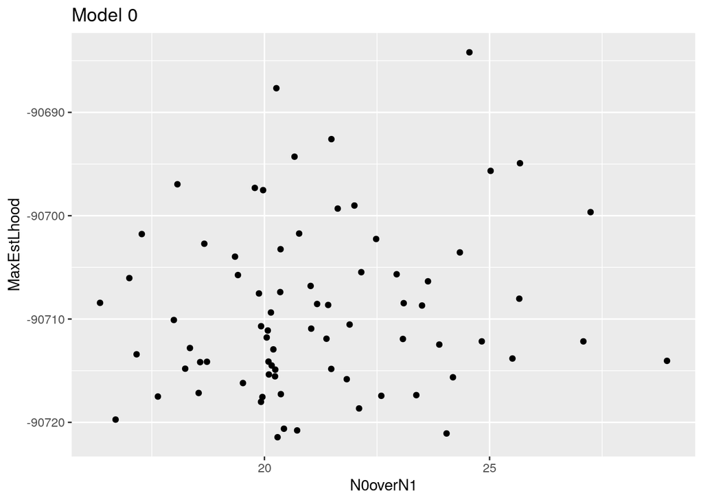

```r
model0$N0overN1 <- model0$NPOP0 / model0$NPOP1
model1$N0overN1 <- model1$NPOP0 / model1$NPOP1

ggplot(data = model0, mapping = aes(x = N0overN1, y = MaxEstLhood)) +
   geom_point() + ggtitle('Model 0')
```

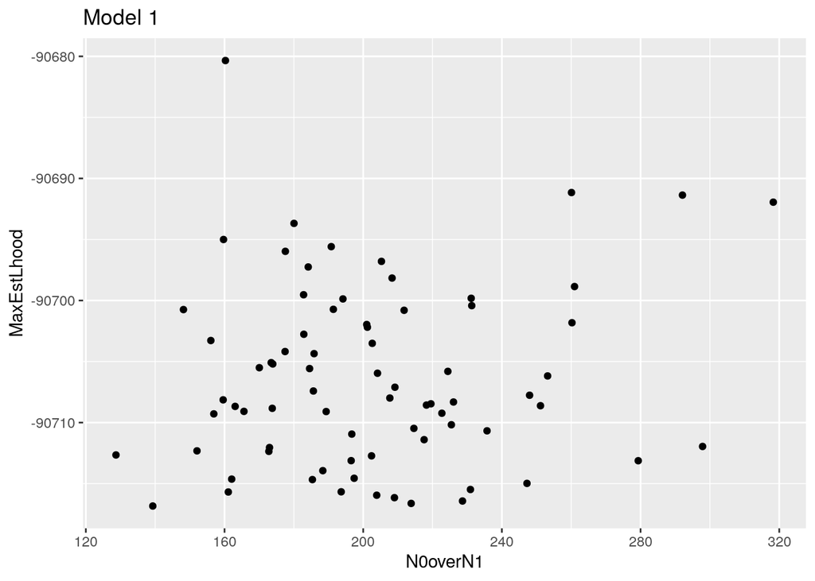

```r
ggplot(data = model1, mapping = aes(x = N0overN1, y = MaxEstLhood)) +
   geom_point() + ggtitle('Model 1')
```

So, it seems that Langfjordvatn maintains a population around either 20 (model 0) or 200 (model 1) times larger than that in Suopatjavri.